```python
import torch
import torch.nn as nn
from torch.utils.data import Dataset
import torchvision.transforms.functional as TF
import albumentations as A
from albumentations.pytorch import ToTensorV2
import torchvision
from torch.utils.data import DataLoader
import torch.optim as optim

from PIL import Image
import numpy as np
from tqdm import tqdm
import os
import matplotlib.pyplot as plt
```

# Tarefa 2 Deep Learning - Segmentação de Imagens

- Maruan Bakri Ottoni
- Número USP: 13710368

O objetivo desta tarefa foi o exercício prático de conceitos, técnicas e métodos vistos ou relacionados ao conteúdo coberto nas aulas. Especificamente, o foco será a familiarização prática com Redes Neurais Totalmente Convolucionais (aqui foi usado a U-NET), para segmentação de imagens.

Nesse notebook foi feita a implementação da UNET e a segmentação de imagens médicas do conjunto de dados DRIVE.

## Dificuldades Enfrentadas e comentários em relação a tarefa

Na realização dessa tarefa eu tive bastante dificuldade em sua execução. As dificuldades dela envolveram o entendimento da arquitetura e como transformar o desenho da arquitetura do artigo em uma solução em código. Isso foi acentuado pela minha pouca familiaridade com o PyTorch, sendo que eu escolhi essa biblioteca para justamente poder aprender ela de forma melhor.

Outra dificuldade encontrada na realização dessa tarefa foi em relação a rodar o código em uma máquina com arquitetura ARM. Haja vista que o PyTorch não é otimizado para rodar com a arquitetura ARM isso resultou em uma dor de cabeça desnecessária, sendo que a solução final encontrada foi de rodar o código no google colab com o CUDA ativado.

Em geral, embora a tarefa foi bem desafiadora, eu gostei bastante de fazer ela. Ela foi uma ótima oportunidade de aprendizado e sinto que eu atinge meus objetivos de aprendizado ao realizar ela.

## Fontes utilizadas

- https://pytorch.org/docs/stable/index.html
- https://arxiv.org/pdf/1505.04597.pdf

# Definição dos diretorios utilizados

Aqui é necessário alterar caso você deseje rodar esse notebook.

```
* Caso você deseje rodar no drive é necessario ter no seu google drive uma pasta denominada data_drive com o dataset nessa localizacao '/content/drive/MyDrive/data_drive'

* Caso você deseje rodar localmente é tambem necessario alterar essa parte do notebook com os devidos paths relativos ao dataset

* Os formatos dos nomes das imagens estão da seguinte forma. Caso eles não estejam nesse formato é necessário alterar.
    * Para dados de treino em train_images/ teremos "{numero}_training.tif"
    * Para dados de treino em train_masks/ teremos "{numero}_training_mask.png"
    * Para dados de validação em val_images/ teremos "{numero}_test.tif"
    * Para dados de validação em val_images/ teremos "{numero}_test_mask.png"

* O resultado das predições é salvo no folder "saved_images"
```

```python
#directory_path = "/content/drive/MyDrive/data_drive/saved_images"
directory_path = "saved_images"
os.makedirs(directory_path, exist_ok=True)
```

```python
from google.colab import drive
drive.mount('/content/drive')
```

```python
os.listdir('/content/drive/MyDrive/data_drive')
```

```
['drive.zip',
 '.DS_Store',
 'val_masks',
 'train_images',
 'previous',
 'val_images',
 'train_masks',
 'saved_images']
```

# Funções Auxiliares

```python
"""
Salva um estado em disco em formato ".pth.tar".

Parâmetros:
    - state (objeto): O estado a ser salvo.
    - filename (string, opcional): Nome do arquivo de saída. Padrão: "my_checkpoint.pth.tar".
"""

def save_checkpoint(state, filename="my_checkpoint.pth.tar"):
    print("=> Saving checkpoint")
    torch.save(state, filename)
```

```python
"""
Carrega um checkpoint salvo anteriormente em um modelo.

Parâmetros:
    - checkpoint (objeto): O checkpoint a ser carregado, geralmente contendo os parâmetros do modelo.
    - model (objeto): O modelo no qual os parâmetros do checkpoint serão carregados.
"""

def load_checkpoint(checkpoint, model):
    print("=> Loading checkpoint")
    model.load_state_dict(checkpoint["state_dict"])
```

```python
"""
Verifica a precisão de um modelo em um conjunto de dados.

Parâmetros:
    - loader (objeto): O carregador de dados que fornece os dados de entrada e rótulos.
    - model (objeto): O modelo a ser avaliado.
    - device (string, opcional): O dispositivo de computação a ser usado para a avaliação. Padrão: "cuda".

Observações:
    Esta função calcula a precisão e o escore Dice do modelo em um conjunto de dados.
    É usado durante a avaliação do desempenho do modelo após o treinamento.
"""

def check_accuracy(loader, model, device="cuda"):
    num_correct = 0
    num_pixels = 0
    dice_score = 0 # https://towardsdatascience.com/metrics-to-evaluate-your-semantic-segmentation-model-6bcb99639aa2
    model.eval()

    with torch.no_grad():
        for x, y in loader:
            x = x.to(device)
            y = y.to(device).unsqueeze(1)
            preds = torch.sigmoid(model(x))
            preds = (preds > 0.5).float()
            num_correct += (preds == y).sum()
            num_pixels += torch.numel(preds)
            dice_score += (2 * (preds * y).sum()) / (
                (preds + y).sum() + 1e-8
            )

    print(
        f"Got {num_correct}/{num_pixels} with acc {num_correct/num_pixels*100:.2f}"
    )
    print(f"Dice score: {dice_score/len(loader)}")
    model.train()

    return (dice_score/len(loader)).cpu().numpy()
```

```python
"""
Salva as previsões de um modelo como imagens em um diretório.

Parâmetros:
    - loader (objeto): O carregador de dados que fornece os dados de entrada e rótulos.
    - model (objeto): O modelo que faz previsões.
    - folder (string, opcional): O diretório onde as imagens de previsão serão salvas. Padrão: "saved_images/".
    - device (string, opcional): O dispositivo de computação a ser usado para a avaliação. Padrão: "cuda".

Observações:
    Esta função gera imagens das previsões do modelo e dos rótulos reais e as salva em um diretório.
    É útil para visualizar as previsões do modelo em um conjunto de dados.
"""

def save_predictions_as_imgs(
    loader, model, folder="saved_images/", device="cuda"
):
    model.eval()
    for idx, (x, y) in enumerate(loader):
        x = x.to(device=device)
        with torch.no_grad():
            preds = torch.sigmoid(model(x))
            preds = (preds > 0.5).float()
        torchvision.utils.save_image(
            preds, f"{folder}/pred_{idx}.png"
        )
        torchvision.utils.save_image(y.unsqueeze(1), f"{folder}{idx}.png")

    model.train()
```

```python
"""
Classe de conjunto de dados personalizado para carregar imagens e máscaras correspondentes.

Parâmetros:
    - image_dir (str): Diretório contendo as imagens.
    - mask_dir (str): Diretório contendo as máscaras correspondentes.
    - transform (callable, opcional): Transformações a serem aplicadas às imagens e máscaras. Padrão: None.

Métodos:
    - __len__(): Retorna o número de amostras no conjunto de dados.
    - __getitem__(index): Retorna uma amostra específica (imagem e máscara) do conjunto de dados.

Observações:
    Esta classe é usada para carregar pares de imagens e máscaras correspondentes de um diretório.
    As imagens são carregadas no formato RGB, enquanto as máscaras são carregadas como imagens em escala de cinza.
    A função de ativação Sigmoid é aplicada às máscaras para ajustá-las entre 0 e 1.
    A transformação (se especificada) pode ser usada para aplicar aumentos de dados às imagens e máscaras.
"""
class Data(Dataset):
    def __init__(self, image_dir, mask_dir, transform=None):
        self.image_dir = image_dir
        self.mask_dir = mask_dir
        self.transform = transform
        self.images = os.listdir(image_dir)

    def __len__(self):
        return len(self.images)

    def __getitem__(self, index):
        img_path = os.path.join(self.image_dir, self.images[index])
        mask_path = os.path.join(self.mask_dir, self.images[index].replace(".tif", "_mask.png"))
        print(mask_path)
        image = np.array(Image.open(img_path).convert("RGB"))
        mask = np.array(Image.open(mask_path).convert("L"), dtype=np.float32) # L is for grayscale
        mask[ mask == 255.0 ] = 1.0 # Sigmoid on the last activation

        if self.transform is not None:
            augmentations = self.transform(image=image, mask=mask)
            image = augmentations["image"]
            mask = augmentations["mask"]

        return image, mask
```

```python
"""
    Obtém carregadores de dados para treinamento e validação.

    Parâmetros:
        - train_dir (str): Diretório contendo imagens de treinamento.
        - train_maskdir (str): Diretório contendo máscaras de treinamento correspondentes.
        - val_dir (str): Diretório contendo imagens de validação.
        - val_maskdir (str): Diretório contendo máscaras de validação correspondentes.
        - batch_size (int): Tamanho do lote para carregamento de dados.
        - train_transform (callable): Transformações a serem aplicadas às imagens de treinamento.
        - val_transform (callable): Transformações a serem aplicadas às imagens de validação.
        - num_workers (int, opcional): Número de processadores para carregamento de dados paralelo. Padrão: 4.
        - pin_memory (bool, opcional): Se deve usar pin_memory para transferir dados para GPU. Padrão: True.

    Retorna:
        - train_loader (DataLoader): DataLoader para dados de treinamento.
        - val_loader (DataLoader): DataLoader para dados de validação.

    Observações:
        Esta função cria DataLoader para conjuntos de treinamento e validação com as transformações especificadas.
"""
def get_loaders(
    train_dir,
    train_maskdir,
    val_dir,
    val_maskdir,
    batch_size,
    train_transform,
    val_transform,
    num_workers=4,
    pin_memory=True,
):
    train_ds = Data(
        image_dir=train_dir,
        mask_dir=train_maskdir,
        transform=train_transform,
    )

    train_loader = DataLoader(
        train_ds,
        batch_size=batch_size,
        num_workers=num_workers,
        pin_memory=pin_memory,
        shuffle=True,
    )

    val_ds = Data(
        image_dir=val_dir,
        mask_dir=val_maskdir,
        transform=val_transform,
    )

    val_loader = DataLoader(
        val_ds,
        batch_size=batch_size,
        num_workers=num_workers,
        pin_memory=pin_memory,
        shuffle=False,
    )

    return train_loader, val_loader
```

# Definição da Arquitetura do modelo U-NET

[figure not shown]

```python
class DoubleConv(nn.Module):
    """
    Implementa uma sequência de duas camadas convolucionais seguidas de normalização e ativação ReLU.

    Parâmetros:
        - in_channels (int): Número de canais de entrada.
        - out_channels (int): Número de canais de saída após as operações de convolução.

    Métodos:
        - forward(x): Executa a passagem direta (forward pass) da rede.

    Observações:
        Esta classe é frequentemente usada em arquiteturas de redes neurais convolucionais para a extração de características.
        Cada camada convolucional é seguida por uma camada de normalização e ativação ReLU.
    """
    def __init__(self, in_channels, out_channels):
        super(DoubleConv, self).__init__()
        self.conv = nn.Sequential(
            nn.Conv2d(in_channels, out_channels, 3, 1, 1, bias=False),
            nn.BatchNorm2d(out_channels),
            nn.ReLU(inplace=True),
            nn.Conv2d(out_channels, out_channels, 3, 1, 1, bias=False),
            nn.BatchNorm2d(out_channels),
            nn.ReLU(inplace=True),
        )

    def forward(self, x):
        return self.conv(x)
```

```python
class UNET(nn.Module):
    """
    Implementa uma rede UNET para segmentação de imagem.

    Parâmetros:
        - in_channels (int, opcional): Número de canais de entrada. Padrão: 3.
        - out_channels (int, opcional): Número de canais de saída. Padrão: 1.
        - features (list, opcional): Lista das características (número de canais) em cada camada. Padrão: [64, 128, 256, 512].

    Métodos:
        - forward(x): Executa a passagem direta (forward pass) da rede.

    Observações:
        A classe UNET é usada para tarefas de segmentação de imagem, onde a entrada é uma imagem e a saída é um mapa de segmentação.
        A rede UNET consiste em uma parte de descida (down) e uma parte de subida (up), com conexões skip para preservar detalhes.
        As camadas convolucionais duplas (DoubleConv) são usadas para extração de características.
    """
    def __init__(
            self, in_channels=3, out_channels=1, features=[64, 128, 256, 512],
    ):
        super(UNET, self).__init__()
        self.ups = nn.ModuleList()
        self.downs = nn.ModuleList()
        self.pool = nn.MaxPool2d(kernel_size=2, stride=2)

        # Down part of UNET
        for feature in features:
            self.downs.append(DoubleConv(in_channels, feature))
            in_channels = feature

        # Up part of UNET
        for feature in reversed(features):
            self.ups.append(
                nn.ConvTranspose2d(
                    feature*2, feature, kernel_size=2, stride=2,
                )
            )
            self.ups.append(DoubleConv(feature*2, feature))

        self.bottleneck = DoubleConv(features[-1], features[-1]*2)
        self.final_conv = nn.Conv2d(features[0], out_channels, kernel_size=1)

    def forward(self, x):
        skip_connections = []

        for down in self.downs:
            x = down(x)
            skip_connections.append(x)
            x = self.pool(x)

        x = self.bottleneck(x)
        skip_connections = skip_connections[::-1]

        for idx in range(0, len(self.ups), 2):
            x = self.ups[idx](x)
            skip_connection = skip_connections[idx//2]

            if x.shape != skip_connection.shape:
                x = TF.resize(x, size=skip_connection.shape[2:])

            concat_skip = torch.cat((skip_connection, x), dim=1)
            x = self.ups[idx+1](concat_skip)

        return self.final_conv(x)
```

```python
def test():
    """
    Função de teste para verificar a funcionalidade da classe UNET.

    Observações:
        - Gera um tensor de entrada aleatório `x`.
        - Instancia um modelo UNET.
        - Faz previsões usando o modelo e verifica se as dimensões das previsões são iguais às do tensor de entrada `x`.
        - Levanta uma exceção AssertionError se as dimensões não forem iguais.
    """
    x = torch.randn((3, 1, 161, 161))
    model = UNET(in_channels=1, out_channels=1)
    preds = model(x)
    assert preds.shape == x.shape

test()
```

# Hiperparâmetros

```python
# Hyperparameters etc.
LEARNING_RATE = 1e-4

if torch.cuda.is_available():
    DEVICE = "cuda"
elif torch.backends.mps.is_available():
    DEVICE = "mps"
else:
    DEVICE = "cpu"

BATCH_SIZE = 2
NUM_EPOCHS = 20
NUM_WORKERS = 4
IMAGE_HEIGHT = 200  # 584 originally
IMAGE_WIDTH = 180  # 565 originally
PIN_MEMORY = True
LOAD_MODEL = False

path = '/content/drive/MyDrive/data_drive/'
TRAIN_IMG_DIR = path+"train_images/"
TRAIN_MASK_DIR = path+"train_masks/"
VAL_IMG_DIR = path+"val_images/"
VAL_MASK_DIR = path+"val_masks/"
```

# Treinamento do modelo

```python
def train_fn(loader, model, optimizer, loss_fn, scaler):
    """
    Realiza um ciclo de treinamento em um modelo de rede neural.

    Parâmetros:
        - loader (objeto): O carregador de dados que fornece os lotes de treinamento.
        - model (objeto): O modelo de rede neural a ser treinado.
        - optimizer (objeto): O otimizador usado para ajustar os pesos do modelo.
        - loss_fn (objeto): A função de perda usada para calcular o erro entre previsões e rótulos.
        - scaler (objeto): O scaler para uso com a precisão mista (mixed-precision training).

    Observações:
        - Itera sobre os lotes de dados do carregador.
        - Move os dados e rótulos para o dispositivo de treinamento (normalmente GPU).
        - Realiza a passagem direta (forward pass) do modelo e calcula a perda.
        - Realiza a retropropagação do gradiente e atualiza os pesos do modelo usando o otimizador.
        - Atualiza o loop de progresso (tqdm) com informações sobre a perda.
    """
    loop = tqdm(loader)

    for batch_idx, (data, targets) in enumerate(loop):
        data = data.to(device=DEVICE)
        targets = targets.float().unsqueeze(1).to(device=DEVICE)

        # forward
        with torch.cuda.amp.autocast():
            predictions = model(data)
            loss = loss_fn(predictions, targets)

        # backward
        optimizer.zero_grad()
        scaler.scale(loss).backward()
        scaler.step(optimizer)
        scaler.update()

        # update tqdm loop
        loop.set_postfix(loss=loss.item())

    return loss.detach().cpu().numpy()
```

```python
def main():
    """
    Função principal para treinar e avaliar um modelo de segmentação de imagem UNET.

    Observações:
        - Define transformações de dados para treinamento e validação, incluindo redimensionamento, rotação e normalização.
        - Instancia um modelo UNET, uma função de perda, um otimizador e carrega checkpoints (se especificado).
        - Obtém carregadores de dados para treinamento e validação.
        - Avalia a precisão do modelo antes do treinamento.
        - Realiza o treinamento do modelo em várias épocas.
        - Salva checkpoints do modelo durante o treinamento.
        - Avalia a precisão do modelo após cada época.
        - Salva previsões do modelo como imagens para visualização.
    """
    train_transform = A.Compose(
        [
            A.Resize(height=IMAGE_HEIGHT, width=IMAGE_WIDTH),  # Redimensiona as imagens de treinamento.
            A.Rotate(limit=35, p=1.0),  # Aplica rotação aleatória com limite de 35 graus.
            A.HorizontalFlip(p=0.5),  # Aplica flip horizontal com probabilidade de 0.5.
            A.VerticalFlip(p=0.1),  # Aplica flip vertical com probabilidade de 0.1.
            A.Normalize(  # Normaliza os valores de pixel das imagens.
                mean=[0.0, 0.0, 0.0],  # Média dos canais de cores.
                std=[1.0, 1.0, 1.0],  # Desvio padrão dos canais de cores.
                max_pixel_value=255.0,  # Valor máximo do pixel.
            ),
            ToTensorV2(),  # Converte as imagens para tensores do PyTorch.
        ],
    )

    val_transforms = A.Compose(
        [
            A.Resize(height=IMAGE_HEIGHT, width=IMAGE_WIDTH),  # Redimensiona as imagens de validação.
            A.Normalize(  # Normaliza os valores de pixel das imagens.
                mean=[0.0, 0.0, 0.0],  # Média dos canais de cores.
                std=[1.0, 1.0, 1.0],  # Desvio padrão dos canais de cores.
                max_pixel_value=255.0,  # Valor máximo do pixel.
            ),
            ToTensorV2(),  # Converte as imagens para tensores do PyTorch.
        ],
    )

    model = UNET(in_channels=3, out_channels=1).to(DEVICE)  # Instancia um modelo UNET.
    loss_fn = nn.BCEWithLogitsLoss()  # Função de perda para treinamento.
    optimizer = optim.Adam(model.parameters(), lr=LEARNING_RATE)  # Otimizador Adam.

    # Obtém carregadores de dados para treinamento e validação.
    train_loader, val_loader = get_loaders(
        TRAIN_IMG_DIR,
        TRAIN_MASK_DIR,
        VAL_IMG_DIR,
        VAL_MASK_DIR,
        BATCH_SIZE,
        train_transform,
        val_transforms,
        NUM_WORKERS,
        PIN_MEMORY,
    )

    if LOAD_MODEL:  # Carrega um checkpoint se LOAD_MODEL for True.
        load_checkpoint(torch.load("my_checkpoint.pth.tar"), model)

    check_accuracy(val_loader, model, device=DEVICE)  # Avalia a precisão do modelo antes do treinamento.
    scaler = torch.cuda.amp.GradScaler()  # Configura um scaler para precisão mista.

    accs, losses = list(), list()
    for epoch in range(NUM_EPOCHS):  # Loop de treinamento para várias épocas.
        loss = train_fn(train_loader, model, optimizer, loss_fn, scaler)  # Treina o modelo.
        losses.append(loss)

        # Salva um checkpoint do modelo após cada época.
        checkpoint = {
            "state_dict": model.state_dict(),
            "optimizer": optimizer.state_dict(),
        }
        save_checkpoint(checkpoint)

        # Avalia a precisão do modelo após cada época.
        acc = check_accuracy(val_loader, model, device=DEVICE)
        accs.append(acc)

        # Salva previsões do modelo como imagens para visualização.
        save_predictions_as_imgs(
            val_loader, model, folder="saved_images/", device=DEVICE
        )

    return accs, losses
```

```python
accs, losses = main()
```

```
/content/drive/MyDrive/data_drive/val_masks/02_test_mask.png/content/drive/MyDrive/data_drive/val_masks/01_test_mask.png
/content/drive/MyDrive/data_drive/val_masks/05_test_mask.png

/content/drive/MyDrive/data_drive/val_masks/06_test_mask.png
/content/drive/MyDrive/data_drive/val_masks/04_test_mask.png/content/drive/MyDrive/data_drive/val_masks/08_test_mask.png/content/drive/MyDrive/data_drive/val_masks/03_test_mask.png/content/drive/MyDrive/data_drive/val_masks/07_test_mask.png



/content/drive/MyDrive/data_drive/val_masks/11_test_mask.png
/content/drive/MyDrive/data_drive/val_masks/13_test_mask.png
/content/drive/MyDrive/data_drive/val_masks/10_test_mask.png
/content/drive/MyDrive/data_drive/val_masks/14_test_mask.png
/content/drive/MyDrive/data_drive/val_masks/12_test_mask.png
/content/drive/MyDrive/data_drive/val_masks/15_test_mask.png
/content/drive/MyDrive/data_drive/val_masks/09_test_mask.png
/content/drive/MyDrive/data_drive/val_masks/18_test_mask.png
/content/drive/MyDrive/data_drive/val_masks/17_test_mask.png
/content/drive/MyDrive/data_drive/val_masks/16_test_mask.png
/content/drive/MyDrive/data_drive/val_masks/19_test_mask.png
/content/drive/MyDrive/data_drive/val_masks/20_test_mask.png
Got 656985/720000 with acc 91.25
Dice score: 0.0
```

[output not shown]

[output not shown]

```
=> Saving checkpoint
/content/drive/MyDrive/data_drive/val_masks/02_test_mask.png
/content/drive/MyDrive/data_drive/val_masks/01_test_mask.png
/content/drive/MyDrive/data_drive/val_masks/05_test_mask.png
/content/drive/MyDrive/data_drive/val_masks/06_test_mask.png
/content/drive/MyDrive/data_drive/val_masks/04_test_mask.png/content/drive/MyDrive/data_drive/val_masks/03_test_mask.png

/content/drive/MyDrive/data_drive/val_masks/07_test_mask.png
/content/drive/MyDrive/data_drive/val_masks/08_test_mask.png
/content/drive/MyDrive/data_drive/val_masks/10_test_mask.png
/content/drive/MyDrive/data_drive/val_masks/11_test_mask.png
/content/drive/MyDrive/data_drive/val_masks/13_test_mask.png
/content/drive/MyDrive/data_drive/val_masks/14_test_mask.png
/content/drive/MyDrive/data_drive/val_masks/09_test_mask.png
/content/drive/MyDrive/data_drive/val_masks/12_test_mask.png
/content/drive/MyDrive/data_drive/val_masks/15_test_mask.png
/content/drive/MyDrive/data_drive/val_masks/18_test_mask.png
/content/drive/MyDrive/data_drive/val_masks/17_test_mask.png
/content/drive/MyDrive/data_drive/val_masks/19_test_mask.png
/content/drive/MyDrive/data_drive/val_masks/16_test_mask.png
/content/drive/MyDrive/data_drive/val_masks/20_test_mask.png
Got 656985/720000 with acc 91.25
Dice score: 0.0
/content/drive/MyDrive/data_drive/val_masks/02_test_mask.png/content/drive/MyDrive/data_drive/val_masks/01_test_mask.png
/content/drive/MyDrive/data_drive/val_masks/05_test_mask.png
/content/drive/MyDrive/data_drive/val_masks/06_test_mask.png

/content/drive/MyDrive/data_drive/val_masks/03_test_mask.png
/content/drive/MyDrive/data_drive/val_masks/04_test_mask.png
/content/drive/MyDrive/data_drive/val_masks/07_test_mask.png
/content/drive/MyDrive/data_drive/val_masks/08_test_mask.png
/content/drive/MyDrive/data_drive/val_masks/10_test_mask.png
/content/drive/MyDrive/data_drive/val_masks/11_test_mask.png
/content/drive/MyDrive/data_drive/val_masks/13_test_mask.png
/content/drive/MyDrive/data_drive/val_masks/14_test_mask.png/content/drive/MyDrive/data_drive/val_masks/09_test_mask.png

/content/drive/MyDrive/data_drive/val_masks/12_test_mask.png
/content/drive/MyDrive/data_drive/val_masks/15_test_mask.png
/content/drive/MyDrive/data_drive/val_masks/17_test_mask.png
/content/drive/MyDrive/data_drive/val_masks/18_test_mask.png
/content/drive/MyDrive/data_drive/val_masks/19_test_mask.png
/content/drive/MyDrive/data_drive/val_masks/16_test_mask.png
/content/drive/MyDrive/data_drive/val_masks/20_test_mask.png
```

[output not shown]

[output not shown]

[output not shown]

```
=> Saving checkpoint
/content/drive/MyDrive/data_drive/val_masks/02_test_mask.png/content/drive/MyDrive/data_drive/val_masks/01_test_mask.png/content/drive/MyDrive/data_drive/val_masks/06_test_mask.png/content/drive/MyDrive/data_drive/val_masks/05_test_mask.png



/content/drive/MyDrive/data_drive/val_masks/04_test_mask.png/content/drive/MyDrive/data_drive/val_masks/08_test_mask.png/content/drive/MyDrive/data_drive/val_masks/03_test_mask.png

/content/drive/MyDrive/data_drive/val_masks/07_test_mask.png

/content/drive/MyDrive/data_drive/val_masks/14_test_mask.png
/content/drive/MyDrive/data_drive/val_masks/13_test_mask.png/content/drive/MyDrive/data_drive/val_masks/10_test_mask.png/content/drive/MyDrive/data_drive/val_masks/18_test_mask.png/content/drive/MyDrive/data_drive/val_masks/11_test_mask.png



/content/drive/MyDrive/data_drive/val_masks/09_test_mask.png
/content/drive/MyDrive/data_drive/val_masks/12_test_mask.png
/content/drive/MyDrive/data_drive/val_masks/19_test_mask.png
/content/drive/MyDrive/data_drive/val_masks/15_test_mask.png/content/drive/MyDrive/data_drive/val_masks/17_test_mask.png

/content/drive/MyDrive/data_drive/val_masks/20_test_mask.png/content/drive/MyDrive/data_drive/val_masks/16_test_mask.png

Got 656985/720000 with acc 91.25
Dice score: 0.0
/content/drive/MyDrive/data_drive/val_masks/02_test_mask.png/content/drive/MyDrive/data_drive/val_masks/05_test_mask.png/content/drive/MyDrive/data_drive/val_masks/01_test_mask.png/content/drive/MyDrive/data_drive/val_masks/06_test_mask.png



/content/drive/MyDrive/data_drive/val_masks/04_test_mask.png
/content/drive/MyDrive/data_drive/val_masks/03_test_mask.png
/content/drive/MyDrive/data_drive/val_masks/07_test_mask.png
/content/drive/MyDrive/data_drive/val_masks/08_test_mask.png
/content/drive/MyDrive/data_drive/val_masks/11_test_mask.png
/content/drive/MyDrive/data_drive/val_masks/14_test_mask.png/content/drive/MyDrive/data_drive/val_masks/10_test_mask.png
/content/drive/MyDrive/data_drive/val_masks/13_test_mask.png

/content/drive/MyDrive/data_drive/val_masks/12_test_mask.png
/content/drive/MyDrive/data_drive/val_masks/18_test_mask.png
/content/drive/MyDrive/data_drive/val_masks/09_test_mask.png
/content/drive/MyDrive/data_drive/val_masks/15_test_mask.png
/content/drive/MyDrive/data_drive/val_masks/19_test_mask.png
/content/drive/MyDrive/data_drive/val_masks/17_test_mask.png
/content/drive/MyDrive/data_drive/val_masks/20_test_mask.png/content/drive/MyDrive/data_drive/val_masks/16_test_mask.png
```

[output not shown]

[output not shown]

[output not shown]

[output not shown]

```
=> Saving checkpoint
/content/drive/MyDrive/data_drive/val_masks/02_test_mask.png/content/drive/MyDrive/data_drive/val_masks/01_test_mask.png/content/drive/MyDrive/data_drive/val_masks/06_test_mask.png
/content/drive/MyDrive/data_drive/val_masks/05_test_mask.png


/content/drive/MyDrive/data_drive/val_masks/03_test_mask.png/content/drive/MyDrive/data_drive/val_masks/04_test_mask.png

/content/drive/MyDrive/data_drive/val_masks/07_test_mask.png/content/drive/MyDrive/data_drive/val_masks/08_test_mask.png

/content/drive/MyDrive/data_drive/val_masks/10_test_mask.png/content/drive/MyDrive/data_drive/val_masks/11_test_mask.png

/content/drive/MyDrive/data_drive/val_masks/14_test_mask.png
/content/drive/MyDrive/data_drive/val_masks/13_test_mask.png/content/drive/MyDrive/data_drive/val_masks/09_test_mask.png

/content/drive/MyDrive/data_drive/val_masks/12_test_mask.png
/content/drive/MyDrive/data_drive/val_masks/18_test_mask.png
/content/drive/MyDrive/data_drive/val_masks/15_test_mask.png
/content/drive/MyDrive/data_drive/val_masks/17_test_mask.png
/content/drive/MyDrive/data_drive/val_masks/19_test_mask.png
/content/drive/MyDrive/data_drive/val_masks/16_test_mask.png
/content/drive/MyDrive/data_drive/val_masks/20_test_mask.png
Got 656785/720000 with acc 91.22
Dice score: 0.0008789614657871425
/content/drive/MyDrive/data_drive/val_masks/02_test_mask.png/content/drive/MyDrive/data_drive/val_masks/01_test_mask.png/content/drive/MyDrive/data_drive/val_masks/05_test_mask.png


/content/drive/MyDrive/data_drive/val_masks/06_test_mask.png
/content/drive/MyDrive/data_drive/val_masks/04_test_mask.png/content/drive/MyDrive/data_drive/val_masks/07_test_mask.png

/content/drive/MyDrive/data_drive/val_masks/08_test_mask.png
/content/drive/MyDrive/data_drive/val_masks/03_test_mask.png
/content/drive/MyDrive/data_drive/val_masks/13_test_mask.png/content/drive/MyDrive/data_drive/val_masks/11_test_mask.png/content/drive/MyDrive/data_drive/val_masks/14_test_mask.png/content/drive/MyDrive/data_drive/val_masks/10_test_mask.png



/content/drive/MyDrive/data_drive/val_masks/18_test_mask.png/content/drive/MyDrive/data_drive/val_masks/12_test_mask.png/content/drive/MyDrive/data_drive/val_masks/09_test_mask.png

/content/drive/MyDrive/data_drive/val_masks/15_test_mask.png

/content/drive/MyDrive/data_drive/val_masks/17_test_mask.png/content/drive/MyDrive/data_drive/val_masks/19_test_mask.png

/content/drive/MyDrive/data_drive/val_masks/20_test_mask.png
/content/drive/MyDrive/data_drive/val_masks/16_test_mask.png
```

[output not shown]

[output not shown]

[output not shown]

[output not shown]

```
=> Saving checkpoint
/content/drive/MyDrive/data_drive/val_masks/02_test_mask.png/content/drive/MyDrive/data_drive/val_masks/01_test_mask.png

/content/drive/MyDrive/data_drive/val_masks/05_test_mask.png/content/drive/MyDrive/data_drive/val_masks/06_test_mask.png

/content/drive/MyDrive/data_drive/val_masks/07_test_mask.png
/content/drive/MyDrive/data_drive/val_masks/03_test_mask.png
/content/drive/MyDrive/data_drive/val_masks/04_test_mask.png
/content/drive/MyDrive/data_drive/val_masks/08_test_mask.png
/content/drive/MyDrive/data_drive/val_masks/13_test_mask.png
/content/drive/MyDrive/data_drive/val_masks/14_test_mask.png/content/drive/MyDrive/data_drive/val_masks/10_test_mask.png
/content/drive/MyDrive/data_drive/val_masks/11_test_mask.png
/content/drive/MyDrive/data_drive/val_masks/15_test_mask.png

/content/drive/MyDrive/data_drive/val_masks/09_test_mask.png
/content/drive/MyDrive/data_drive/val_masks/18_test_mask.png
/content/drive/MyDrive/data_drive/val_masks/12_test_mask.png
/content/drive/MyDrive/data_drive/val_masks/17_test_mask.png
/content/drive/MyDrive/data_drive/val_masks/19_test_mask.png
/content/drive/MyDrive/data_drive/val_masks/16_test_mask.png
/content/drive/MyDrive/data_drive/val_masks/20_test_mask.png
Got 657376/720000 with acc 91.30
Dice score: 0.021795615553855896
/content/drive/MyDrive/data_drive/val_masks/02_test_mask.png/content/drive/MyDrive/data_drive/val_masks/05_test_mask.png/content/drive/MyDrive/data_drive/val_masks/01_test_mask.png


/content/drive/MyDrive/data_drive/val_masks/06_test_mask.png
/content/drive/MyDrive/data_drive/val_masks/07_test_mask.png
/content/drive/MyDrive/data_drive/val_masks/13_test_mask.png/content/drive/MyDrive/data_drive/val_masks/04_test_mask.png/content/drive/MyDrive/data_drive/val_masks/03_test_mask.png

/content/drive/MyDrive/data_drive/val_masks/08_test_mask.png

/content/drive/MyDrive/data_drive/val_masks/15_test_mask.png
/content/drive/MyDrive/data_drive/val_masks/14_test_mask.png
/content/drive/MyDrive/data_drive/val_masks/10_test_mask.png/content/drive/MyDrive/data_drive/val_masks/11_test_mask.png

/content/drive/MyDrive/data_drive/val_masks/09_test_mask.png/content/drive/MyDrive/data_drive/val_masks/18_test_mask.png/content/drive/MyDrive/data_drive/val_masks/12_test_mask.png


/content/drive/MyDrive/data_drive/val_masks/17_test_mask.png/content/drive/MyDrive/data_drive/val_masks/19_test_mask.png

/content/drive/MyDrive/data_drive/val_masks/20_test_mask.png
/content/drive/MyDrive/data_drive/val_masks/16_test_mask.png
```

[output not shown]

[output not shown]

[output not shown]

[output not shown]

[output not shown]

[output not shown]

```
=> Saving checkpoint
/content/drive/MyDrive/data_drive/val_masks/02_test_mask.png/content/drive/MyDrive/data_drive/val_masks/05_test_mask.png

/content/drive/MyDrive/data_drive/val_masks/01_test_mask.png/content/drive/MyDrive/data_drive/val_masks/06_test_mask.png

/content/drive/MyDrive/data_drive/val_masks/07_test_mask.png
/content/drive/MyDrive/data_drive/val_masks/13_test_mask.png/content/drive/MyDrive/data_drive/val_masks/03_test_mask.png

/content/drive/MyDrive/data_drive/val_masks/04_test_mask.png/content/drive/MyDrive/data_drive/val_masks/08_test_mask.png

/content/drive/MyDrive/data_drive/val_masks/10_test_mask.png/content/drive/MyDrive/data_drive/val_masks/15_test_mask.png

/content/drive/MyDrive/data_drive/val_masks/14_test_mask.png/content/drive/MyDrive/data_drive/val_masks/11_test_mask.png

/content/drive/MyDrive/data_drive/val_masks/09_test_mask.png
/content/drive/MyDrive/data_drive/val_masks/12_test_mask.png
/content/drive/MyDrive/data_drive/val_masks/18_test_mask.png
/content/drive/MyDrive/data_drive/val_masks/17_test_mask.png
/content/drive/MyDrive/data_drive/val_masks/19_test_mask.png
/content/drive/MyDrive/data_drive/val_masks/20_test_mask.png
/content/drive/MyDrive/data_drive/val_masks/16_test_mask.png
Got 657521/720000 with acc 91.32
Dice score: 0.1758333295583725
/content/drive/MyDrive/data_drive/val_masks/02_test_mask.png/content/drive/MyDrive/data_drive/val_masks/01_test_mask.png/content/drive/MyDrive/data_drive/val_masks/06_test_mask.png/content/drive/MyDrive/data_drive/val_masks/05_test_mask.png



/content/drive/MyDrive/data_drive/val_masks/08_test_mask.png
/content/drive/MyDrive/data_drive/val_masks/07_test_mask.png/content/drive/MyDrive/data_drive/val_masks/04_test_mask.png
/content/drive/MyDrive/data_drive/val_masks/14_test_mask.png
/content/drive/MyDrive/data_drive/val_masks/03_test_mask.png

/content/drive/MyDrive/data_drive/val_masks/13_test_mask.png
/content/drive/MyDrive/data_drive/val_masks/10_test_mask.png/content/drive/MyDrive/data_drive/val_masks/11_test_mask.png
/content/drive/MyDrive/data_drive/val_masks/18_test_mask.png

/content/drive/MyDrive/data_drive/val_masks/15_test_mask.png
/content/drive/MyDrive/data_drive/val_masks/12_test_mask.png/content/drive/MyDrive/data_drive/val_masks/09_test_mask.png

/content/drive/MyDrive/data_drive/val_masks/17_test_mask.png/content/drive/MyDrive/data_drive/val_masks/19_test_mask.png

/content/drive/MyDrive/data_drive/val_masks/16_test_mask.png
/content/drive/MyDrive/data_drive/val_masks/20_test_mask.png
```

[output not shown]

[output not shown]

[output not shown]

[output not shown]

```
=> Saving checkpoint
/content/drive/MyDrive/data_drive/val_masks/01_test_mask.png/content/drive/MyDrive/data_drive/val_masks/05_test_mask.png/content/drive/MyDrive/data_drive/val_masks/02_test_mask.png
/content/drive/MyDrive/data_drive/val_masks/06_test_mask.png


/content/drive/MyDrive/data_drive/val_masks/03_test_mask.png
/content/drive/MyDrive/data_drive/val_masks/07_test_mask.png
/content/drive/MyDrive/data_drive/val_masks/04_test_mask.png/content/drive/MyDrive/data_drive/val_masks/08_test_mask.png

/content/drive/MyDrive/data_drive/val_masks/10_test_mask.png
/content/drive/MyDrive/data_drive/val_masks/11_test_mask.png/content/drive/MyDrive/data_drive/val_masks/13_test_mask.png

/content/drive/MyDrive/data_drive/val_masks/14_test_mask.png
/content/drive/MyDrive/data_drive/val_masks/09_test_mask.png
/content/drive/MyDrive/data_drive/val_masks/12_test_mask.png/content/drive/MyDrive/data_drive/val_masks/15_test_mask.png

/content/drive/MyDrive/data_drive/val_masks/18_test_mask.png
/content/drive/MyDrive/data_drive/val_masks/17_test_mask.png
/content/drive/MyDrive/data_drive/val_masks/19_test_mask.png
/content/drive/MyDrive/data_drive/val_masks/16_test_mask.png
/content/drive/MyDrive/data_drive/val_masks/20_test_mask.png
Got 664787/720000 with acc 92.33
Dice score: 0.39272019267082214
/content/drive/MyDrive/data_drive/val_masks/02_test_mask.png/content/drive/MyDrive/data_drive/val_masks/01_test_mask.png

/content/drive/MyDrive/data_drive/val_masks/06_test_mask.png/content/drive/MyDrive/data_drive/val_masks/05_test_mask.png

/content/drive/MyDrive/data_drive/val_masks/03_test_mask.png
/content/drive/MyDrive/data_drive/val_masks/07_test_mask.png/content/drive/MyDrive/data_drive/val_masks/08_test_mask.png/content/drive/MyDrive/data_drive/val_masks/04_test_mask.png


/content/drive/MyDrive/data_drive/val_masks/10_test_mask.png
/content/drive/MyDrive/data_drive/val_masks/13_test_mask.png
/content/drive/MyDrive/data_drive/val_masks/11_test_mask.png
/content/drive/MyDrive/data_drive/val_masks/14_test_mask.png
/content/drive/MyDrive/data_drive/val_masks/09_test_mask.png
/content/drive/MyDrive/data_drive/val_masks/15_test_mask.png
/content/drive/MyDrive/data_drive/val_masks/12_test_mask.png
/content/drive/MyDrive/data_drive/val_masks/18_test_mask.png
/content/drive/MyDrive/data_drive/val_masks/17_test_mask.png/content/drive/MyDrive/data_drive/val_masks/19_test_mask.png

/content/drive/MyDrive/data_drive/val_masks/16_test_mask.png
/content/drive/MyDrive/data_drive/val_masks/20_test_mask.png
```

[output not shown]

[output not shown]

[output not shown]

```
=> Saving checkpoint
/content/drive/MyDrive/data_drive/val_masks/01_test_mask.png/content/drive/MyDrive/data_drive/val_masks/02_test_mask.png/content/drive/MyDrive/data_drive/val_masks/05_test_mask.png
/content/drive/MyDrive/data_drive/val_masks/06_test_mask.png


/content/drive/MyDrive/data_drive/val_masks/04_test_mask.png
/content/drive/MyDrive/data_drive/val_masks/03_test_mask.png
/content/drive/MyDrive/data_drive/val_masks/08_test_mask.png
/content/drive/MyDrive/data_drive/val_masks/07_test_mask.png
/content/drive/MyDrive/data_drive/val_masks/11_test_mask.png
/content/drive/MyDrive/data_drive/val_masks/10_test_mask.png
/content/drive/MyDrive/data_drive/val_masks/14_test_mask.png
/content/drive/MyDrive/data_drive/val_masks/13_test_mask.png/content/drive/MyDrive/data_drive/val_masks/12_test_mask.png
/content/drive/MyDrive/data_drive/val_masks/09_test_mask.png

/content/drive/MyDrive/data_drive/val_masks/18_test_mask.png
/content/drive/MyDrive/data_drive/val_masks/15_test_mask.png/content/drive/MyDrive/data_drive/val_masks/19_test_mask.png

/content/drive/MyDrive/data_drive/val_masks/17_test_mask.png
/content/drive/MyDrive/data_drive/val_masks/20_test_mask.png/content/drive/MyDrive/data_drive/val_masks/16_test_mask.png

Got 666292/720000 with acc 92.54
Dice score: 0.5326022505760193
/content/drive/MyDrive/data_drive/val_masks/05_test_mask.png/content/drive/MyDrive/data_drive/val_masks/01_test_mask.png/content/drive/MyDrive/data_drive/val_masks/02_test_mask.png


/content/drive/MyDrive/data_drive/val_masks/06_test_mask.png
/content/drive/MyDrive/data_drive/val_masks/07_test_mask.png
/content/drive/MyDrive/data_drive/val_masks/04_test_mask.png
/content/drive/MyDrive/data_drive/val_masks/03_test_mask.png/content/drive/MyDrive/data_drive/val_masks/08_test_mask.png
/content/drive/MyDrive/data_drive/val_masks/13_test_mask.png

/content/drive/MyDrive/data_drive/val_masks/11_test_mask.png
/content/drive/MyDrive/data_drive/val_masks/14_test_mask.png/content/drive/MyDrive/data_drive/val_masks/15_test_mask.png/content/drive/MyDrive/data_drive/val_masks/10_test_mask.png


/content/drive/MyDrive/data_drive/val_masks/12_test_mask.png
/content/drive/MyDrive/data_drive/val_masks/18_test_mask.png/content/drive/MyDrive/data_drive/val_masks/09_test_mask.png

/content/drive/MyDrive/data_drive/val_masks/17_test_mask.png
/content/drive/MyDrive/data_drive/val_masks/19_test_mask.png
/content/drive/MyDrive/data_drive/val_masks/16_test_mask.png/content/drive/MyDrive/data_drive/val_masks/20_test_mask.png
```

[output not shown]

[output not shown]

[output not shown]

[output not shown]

[output not shown]

```
=> Saving checkpoint
/content/drive/MyDrive/data_drive/val_masks/02_test_mask.png/content/drive/MyDrive/data_drive/val_masks/01_test_mask.png/content/drive/MyDrive/data_drive/val_masks/05_test_mask.png


/content/drive/MyDrive/data_drive/val_masks/06_test_mask.png
/content/drive/MyDrive/data_drive/val_masks/07_test_mask.png
/content/drive/MyDrive/data_drive/val_masks/03_test_mask.png/content/drive/MyDrive/data_drive/val_masks/04_test_mask.png/content/drive/MyDrive/data_drive/val_masks/08_test_mask.png


/content/drive/MyDrive/data_drive/val_masks/13_test_mask.png
/content/drive/MyDrive/data_drive/val_masks/10_test_mask.png/content/drive/MyDrive/data_drive/val_masks/14_test_mask.png/content/drive/MyDrive/data_drive/val_masks/11_test_mask.png


/content/drive/MyDrive/data_drive/val_masks/15_test_mask.png
/content/drive/MyDrive/data_drive/val_masks/18_test_mask.png/content/drive/MyDrive/data_drive/val_masks/09_test_mask.png/content/drive/MyDrive/data_drive/val_masks/12_test_mask.png


/content/drive/MyDrive/data_drive/val_masks/19_test_mask.png
/content/drive/MyDrive/data_drive/val_masks/17_test_mask.png
/content/drive/MyDrive/data_drive/val_masks/20_test_mask.png
/content/drive/MyDrive/data_drive/val_masks/16_test_mask.png
Got 668963/720000 with acc 92.91
Dice score: 0.5422627329826355
/content/drive/MyDrive/data_drive/val_masks/02_test_mask.png/content/drive/MyDrive/data_drive/val_masks/05_test_mask.png/content/drive/MyDrive/data_drive/val_masks/01_test_mask.png/content/drive/MyDrive/data_drive/val_masks/06_test_mask.png



/content/drive/MyDrive/data_drive/val_masks/03_test_mask.png
/content/drive/MyDrive/data_drive/val_masks/07_test_mask.png/content/drive/MyDrive/data_drive/val_masks/10_test_mask.png
/content/drive/MyDrive/data_drive/val_masks/08_test_mask.png/content/drive/MyDrive/data_drive/val_masks/04_test_mask.png


/content/drive/MyDrive/data_drive/val_masks/14_test_mask.png
/content/drive/MyDrive/data_drive/val_masks/09_test_mask.png
/content/drive/MyDrive/data_drive/val_masks/11_test_mask.png/content/drive/MyDrive/data_drive/val_masks/13_test_mask.png

/content/drive/MyDrive/data_drive/val_masks/17_test_mask.png/content/drive/MyDrive/data_drive/val_masks/18_test_mask.png

/content/drive/MyDrive/data_drive/val_masks/12_test_mask.png
/content/drive/MyDrive/data_drive/val_masks/15_test_mask.png
/content/drive/MyDrive/data_drive/val_masks/16_test_mask.png
/content/drive/MyDrive/data_drive/val_masks/19_test_mask.png
/content/drive/MyDrive/data_drive/val_masks/20_test_mask.png
```

[output not shown]

[output not shown]

[output not shown]

[output not shown]

[output not shown]

```
=> Saving checkpoint
/content/drive/MyDrive/data_drive/val_masks/02_test_mask.png/content/drive/MyDrive/data_drive/val_masks/05_test_mask.png
/content/drive/MyDrive/data_drive/val_masks/01_test_mask.png
/content/drive/MyDrive/data_drive/val_masks/06_test_mask.png

/content/drive/MyDrive/data_drive/val_masks/03_test_mask.png
/content/drive/MyDrive/data_drive/val_masks/07_test_mask.png/content/drive/MyDrive/data_drive/val_masks/04_test_mask.png

/content/drive/MyDrive/data_drive/val_masks/08_test_mask.png
/content/drive/MyDrive/data_drive/val_masks/10_test_mask.png
/content/drive/MyDrive/data_drive/val_masks/11_test_mask.png/content/drive/MyDrive/data_drive/val_masks/13_test_mask.png
/content/drive/MyDrive/data_drive/val_masks/14_test_mask.png

/content/drive/MyDrive/data_drive/val_masks/09_test_mask.png
/content/drive/MyDrive/data_drive/val_masks/12_test_mask.png/content/drive/MyDrive/data_drive/val_masks/15_test_mask.png/content/drive/MyDrive/data_drive/val_masks/18_test_mask.png


/content/drive/MyDrive/data_drive/val_masks/17_test_mask.png
/content/drive/MyDrive/data_drive/val_masks/19_test_mask.png
/content/drive/MyDrive/data_drive/val_masks/16_test_mask.png/content/drive/MyDrive/data_drive/val_masks/20_test_mask.png

Got 641109/720000 with acc 89.04
Dice score: 0.5084795355796814
/content/drive/MyDrive/data_drive/val_masks/02_test_mask.png/content/drive/MyDrive/data_drive/val_masks/01_test_mask.png

/content/drive/MyDrive/data_drive/val_masks/05_test_mask.png/content/drive/MyDrive/data_drive/val_masks/06_test_mask.png

/content/drive/MyDrive/data_drive/val_masks/08_test_mask.png
/content/drive/MyDrive/data_drive/val_masks/07_test_mask.png
/content/drive/MyDrive/data_drive/val_masks/04_test_mask.png/content/drive/MyDrive/data_drive/val_masks/03_test_mask.png

/content/drive/MyDrive/data_drive/val_masks/14_test_mask.png/content/drive/MyDrive/data_drive/val_masks/13_test_mask.png

/content/drive/MyDrive/data_drive/val_masks/10_test_mask.png/content/drive/MyDrive/data_drive/val_masks/11_test_mask.png

/content/drive/MyDrive/data_drive/val_masks/18_test_mask.png
/content/drive/MyDrive/data_drive/val_masks/15_test_mask.png
/content/drive/MyDrive/data_drive/val_masks/09_test_mask.png
/content/drive/MyDrive/data_drive/val_masks/12_test_mask.png
/content/drive/MyDrive/data_drive/val_masks/17_test_mask.png
/content/drive/MyDrive/data_drive/val_masks/19_test_mask.png
/content/drive/MyDrive/data_drive/val_masks/16_test_mask.png
/content/drive/MyDrive/data_drive/val_masks/20_test_mask.png
```

[output not shown]

[output not shown]

[output not shown]

[output not shown]

[output not shown]

```
=> Saving checkpoint
/content/drive/MyDrive/data_drive/val_masks/01_test_mask.png/content/drive/MyDrive/data_drive/val_masks/02_test_mask.png/content/drive/MyDrive/data_drive/val_masks/05_test_mask.png


/content/drive/MyDrive/data_drive/val_masks/06_test_mask.png
/content/drive/MyDrive/data_drive/val_masks/03_test_mask.png
/content/drive/MyDrive/data_drive/val_masks/04_test_mask.png/content/drive/MyDrive/data_drive/val_masks/08_test_mask.png/content/drive/MyDrive/data_drive/val_masks/07_test_mask.png


/content/drive/MyDrive/data_drive/val_masks/10_test_mask.png
/content/drive/MyDrive/data_drive/val_masks/14_test_mask.png/content/drive/MyDrive/data_drive/val_masks/11_test_mask.png
/content/drive/MyDrive/data_drive/val_masks/13_test_mask.png

/content/drive/MyDrive/data_drive/val_masks/09_test_mask.png
/content/drive/MyDrive/data_drive/val_masks/12_test_mask.png/content/drive/MyDrive/data_drive/val_masks/15_test_mask.png
/content/drive/MyDrive/data_drive/val_masks/18_test_mask.png

/content/drive/MyDrive/data_drive/val_masks/17_test_mask.png
/content/drive/MyDrive/data_drive/val_masks/19_test_mask.png
/content/drive/MyDrive/data_drive/val_masks/16_test_mask.png
/content/drive/MyDrive/data_drive/val_masks/20_test_mask.png
Got 663389/720000 with acc 92.14
Dice score: 0.5794063210487366
/content/drive/MyDrive/data_drive/val_masks/02_test_mask.png/content/drive/MyDrive/data_drive/val_masks/05_test_mask.png
/content/drive/MyDrive/data_drive/val_masks/01_test_mask.png

/content/drive/MyDrive/data_drive/val_masks/06_test_mask.png
/content/drive/MyDrive/data_drive/val_masks/08_test_mask.png
/content/drive/MyDrive/data_drive/val_masks/07_test_mask.png
/content/drive/MyDrive/data_drive/val_masks/04_test_mask.png/content/drive/MyDrive/data_drive/val_masks/14_test_mask.png/content/drive/MyDrive/data_drive/val_masks/03_test_mask.png


/content/drive/MyDrive/data_drive/val_masks/13_test_mask.png/content/drive/MyDrive/data_drive/val_masks/10_test_mask.png
/content/drive/MyDrive/data_drive/val_masks/11_test_mask.png

/content/drive/MyDrive/data_drive/val_masks/09_test_mask.png
/content/drive/MyDrive/data_drive/val_masks/18_test_mask.png
/content/drive/MyDrive/data_drive/val_masks/17_test_mask.png/content/drive/MyDrive/data_drive/val_masks/12_test_mask.png/content/drive/MyDrive/data_drive/val_masks/15_test_mask.png


/content/drive/MyDrive/data_drive/val_masks/16_test_mask.png
/content/drive/MyDrive/data_drive/val_masks/19_test_mask.png
/content/drive/MyDrive/data_drive/val_masks/20_test_mask.png
```

[output not shown]

[output not shown]

[output not shown]

```
=> Saving checkpoint
/content/drive/MyDrive/data_drive/val_masks/02_test_mask.png
/content/drive/MyDrive/data_drive/val_masks/01_test_mask.png
/content/drive/MyDrive/data_drive/val_masks/06_test_mask.png/content/drive/MyDrive/data_drive/val_masks/05_test_mask.png

/content/drive/MyDrive/data_drive/val_masks/04_test_mask.png/content/drive/MyDrive/data_drive/val_masks/03_test_mask.png

/content/drive/MyDrive/data_drive/val_masks/08_test_mask.png
/content/drive/MyDrive/data_drive/val_masks/07_test_mask.png
/content/drive/MyDrive/data_drive/val_masks/11_test_mask.png/content/drive/MyDrive/data_drive/val_masks/10_test_mask.png/content/drive/MyDrive/data_drive/val_masks/13_test_mask.png


/content/drive/MyDrive/data_drive/val_masks/14_test_mask.png
/content/drive/MyDrive/data_drive/val_masks/09_test_mask.png
/content/drive/MyDrive/data_drive/val_masks/12_test_mask.png/content/drive/MyDrive/data_drive/val_masks/15_test_mask.png

/content/drive/MyDrive/data_drive/val_masks/18_test_mask.png
/content/drive/MyDrive/data_drive/val_masks/17_test_mask.png/content/drive/MyDrive/data_drive/val_masks/19_test_mask.png

/content/drive/MyDrive/data_drive/val_masks/16_test_mask.png
/content/drive/MyDrive/data_drive/val_masks/20_test_mask.png
Got 663296/720000 with acc 92.12
Dice score: 0.5808088183403015
/content/drive/MyDrive/data_drive/val_masks/02_test_mask.png
/content/drive/MyDrive/data_drive/val_masks/01_test_mask.png/content/drive/MyDrive/data_drive/val_masks/05_test_mask.png/content/drive/MyDrive/data_drive/val_masks/06_test_mask.png


/content/drive/MyDrive/data_drive/val_masks/03_test_mask.png/content/drive/MyDrive/data_drive/val_masks/07_test_mask.png
/content/drive/MyDrive/data_drive/val_masks/08_test_mask.png

/content/drive/MyDrive/data_drive/val_masks/04_test_mask.png
/content/drive/MyDrive/data_drive/val_masks/13_test_mask.png
/content/drive/MyDrive/data_drive/val_masks/10_test_mask.png/content/drive/MyDrive/data_drive/val_masks/14_test_mask.png

/content/drive/MyDrive/data_drive/val_masks/11_test_mask.png
/content/drive/MyDrive/data_drive/val_masks/09_test_mask.png/content/drive/MyDrive/data_drive/val_masks/15_test_mask.png
/content/drive/MyDrive/data_drive/val_masks/18_test_mask.png

/content/drive/MyDrive/data_drive/val_masks/12_test_mask.png
/content/drive/MyDrive/data_drive/val_masks/17_test_mask.png
/content/drive/MyDrive/data_drive/val_masks/19_test_mask.png
/content/drive/MyDrive/data_drive/val_masks/16_test_mask.png
/content/drive/MyDrive/data_drive/val_masks/20_test_mask.png
```

[output not shown]

[output not shown]

[output not shown]

[output not shown]

[output not shown]

[output not shown]

[output not shown]

[output not shown]

[output not shown]

[output not shown]

[output not shown]

[output not shown]

[output not shown]

[output not shown]

[output not shown]

[output not shown]

[output not shown]

[output not shown]

[output not shown]

[output not shown]

[output not shown]

[output not shown]

[output not shown]

[output not shown]

[output not shown]

[output not shown]

[output not shown]

[output not shown]

[output not shown]

[output not shown]

[output not shown]

[output not shown]

[output not shown]

[output not shown]

[output not shown]

[output not shown]

[output not shown]

[output not shown]

[output not shown]

[output not shown]

[output not shown]

[output not shown]

[output not shown]

[output not shown]

# Resultado Final

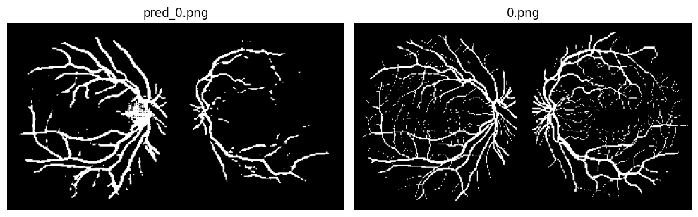

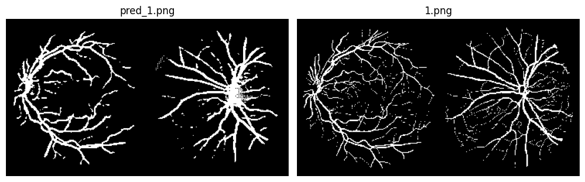

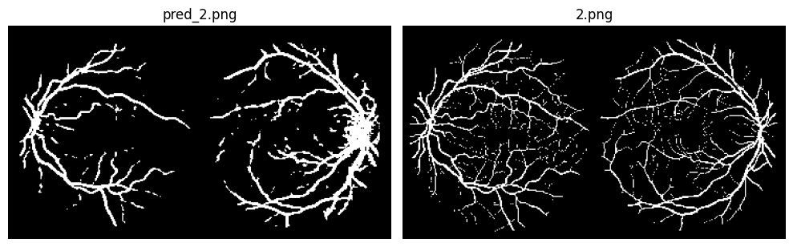

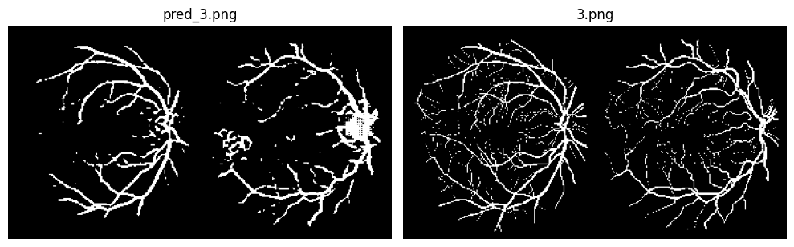

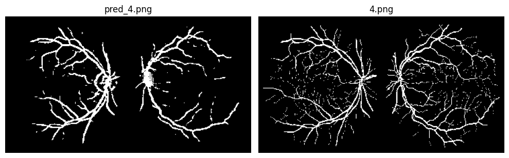

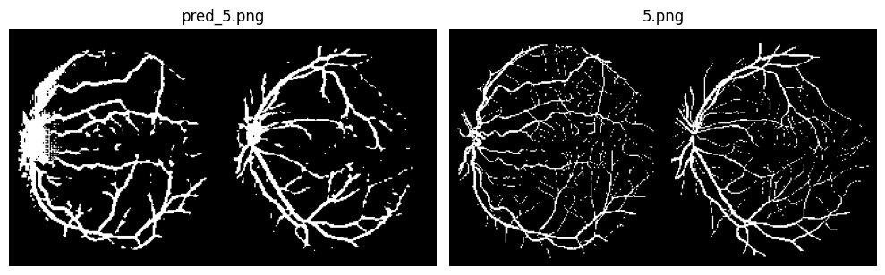

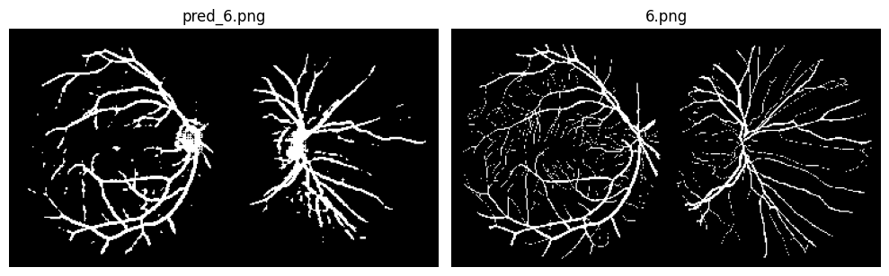

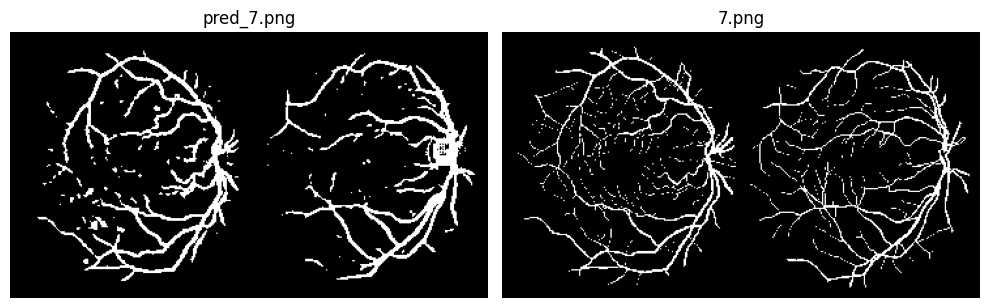

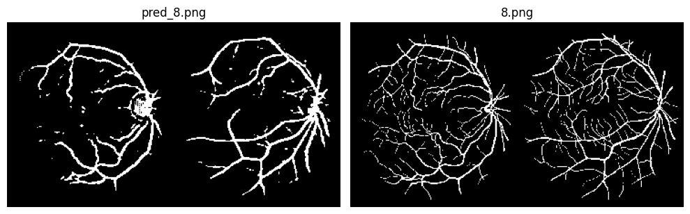

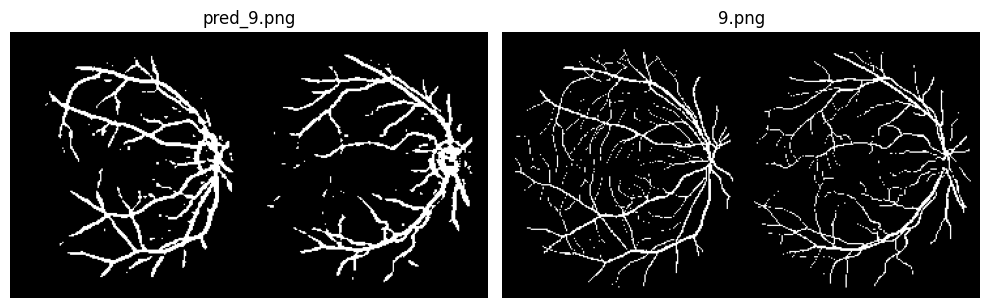

```python
# Create lists for 'pred_' and '' filenames
pred_image_files = [f for f in os.listdir(directory_path) if f.startswith("pred_") and f.endswith(".png")]
mask_image_files = [f for f in os.listdir(directory_path) if f.endswith(".png") and not f.startswith("pred_")]

# Sort the lists to ensure they are in the same order
pred_image_files.sort()
mask_image_files.sort()

# Iterate through both lists and display images side by side
for pred_file, mask_file in zip(pred_image_files, mask_image_files):
    pred_path = os.path.join(directory_path, pred_file)
    mask_path = os.path.join(directory_path, mask_file)

    pred_img = Image.open(pred_path)
    mask_img = Image.open(mask_path)

    # Create a figure with two subplots side by side
    fig, axes = plt.subplots(1, 2, figsize=(10, 5))

    # Display the prediction image on the left subplot
    axes[0].imshow(pred_img)
    axes[0].set_title(pred_file)  # Set the title to the prediction image file name
    axes[0].axis("off")  # Turn off axis labels for the left subplot

    # Display the mask image on the right subplot
    axes[1].imshow(mask_img)
    axes[1].set_title(mask_file)  # Set the title to the mask image file name
    axes[1].axis("off")  # Turn off axis labels for the right subplot

    plt.tight_layout()  # Ensure proper spacing between subplots
    plt.show()
```

[figure not shown]

```python
fig, ax = plt.subplots(1, 2, dpi=80, figsize=(12,10))
ax[0].plot(accs, label='Dice Score')
ax[0].set_title('Accuracy of the training')

ax[1].plot(losses, label='Loss Function')
ax[1].set_title('Loss of the training')
plt.show()
```